# SMART-Seq2 mRNA-Seq of single E7 halves from embryos injected w active/dead-Btgh - embryo filtering and clustering

Sara Formichetti

EMBL Rome  
sara.formichetti@embl.it

August 31st, 2022

# 1 Design of the experiment

| sample | SRR | condition | group_or_time_point | batch | biol_rep | tech_rep | run | library_layout | read_length | sex | tissue | condition_sex | perc_rDNA |
| --- | --- | --- | --- | --- | --- | --- | --- | --- | --- | --- | --- | --- | --- |
| D1_EPI | none | dead_Btgh | M | 1 | 1 | 1 | 1 | PAIRED - | 40 | M | EPI | dead_Btgh_M | 10.03 |
| D1_TROPHO | none | dead_Btgh | M | 1 | 1 | 1 | 1 | PAIRED - | 40 | M | TROPHO | dead_Btgh_M | 15.02 |
| D10_EPI | none | dead_Btgh | M | 1 | 3 | 1 | 1 | PAIRED - | 40 | M | EPI | dead_Btgh_M | 13.07 |
| D10_TROPHO | none | dead_Btgh | M | 1 | 3 | 1 | 1 | PAIRED - | 40 | M | TROPHO | dead_Btgh_M | 10.17 |
| D12_EPI | none | dead_Btgh | F | 1 | 3 | 1 | 1 | PAIRED - | 40 | F | EPI | dead_Btgh_F | 14.44 |
| D12_TROPHO | none | dead_Btgh | F | 1 | 3 | 1 | 1 | PAIRED - | 40 | F | TROPHO | dead_Btgh_F | 13.94 |
| D17_TROPHO | none | dead_Btgh | M | 2 | 4 | 1 | 1 | PAIRED - | 40 | M | TROPHO | dead_Btgh_M | 12.33 |
| D18_TROPHO | none | dead_Btgh | M | 2 | 5 | 1 | 1 | PAIRED - | 40 | M | TROPHO | dead_Btgh_M | 13.96 |
| D19_EPI | none | dead_Btgh | F | 2 | 4 | 1 | 1 | PAIRED - | 40 | F | EPI | dead_Btgh_F | 12.52 |
| D19_TROPHO | none | dead_Btgh | F | 2 | 6 | 1 | 1 | PAIRED - | 40 | F | TROPHO | dead_Btgh_F | 11.77 |
| D2_EPI | none | dead_Btgh | M | 1 | 2 | 1 | 1 | PAIRED - | 40 | M | EPI | dead_Btgh_M | 11.31 |
| D2_TROPHO | none | dead_Btgh | M | 1 | 2 | 1 | 1 | PAIRED - | 40 | M | TROPHO | dead_Btgh_M | 13.19 |
| D20_EPI | none | dead_Btgh | M | 2 | 4 | 1 | 1 | PAIRED - | 40 | M | EPI | dead_Btgh_M | 16.16 |
| D20_TROPHO | none | dead_Btgh | M | 2 | 6 | 1 | 1 | PAIRED - | 40 | M | TROPHO | dead_Btgh_M | 7.65 |
| D21_EPI | none | dead_Btgh | F | 2 | 5 | 1 | 1 | PAIRED - | 40 | F | EPI | dead_Btgh_F | 10.67 |
| D21_TROPHO | none | dead_Btgh | F | 2 | 4 | 1 | 1 | PAIRED - | 40 | F | TROPHO | dead_Btgh_F | 7.41 |
| D22_EPI | none | dead_Btgh | M | 2 | 6 | 1 | 1 | PAIRED - | 40 | M | EPI | dead_Btgh_M | 9.39 |
| D24_EPI | none | dead_Btgh | M | 2 | 5 | 1 | 1 | PAIRED - | 40 | M | EPI | dead_Btgh_M | 11.67 |
| D24_TROPHO | none | dead_Btgh | M | 2 | 7 | 1 | 1 | PAIRED - | 40 | M | TROPHO | dead_Btgh_M | 5.86 |
| D25_EPI | none | dead_Btgh | M | 2 | 7 | 1 | 1 | PAIRED - | 40 | M | EPI | dead_Btgh_M | 14.72 |
| D27_TROPHO | none | dead_Btgh | F | 2 | 5 | 1 | 1 | PAIRED - | 40 | F | TROPHO | dead_Btgh_F | 9.28 |
| D4_EPI | none | dead_Btgh | F | 1 | 1 | 1 | 1 | PAIRED - | 40 | F | EPI | dead_Btgh_F | 11.91 |
| D4_TROPHO | none | dead_Btgh | F | 1 | 1 | 1 | 1 | PAIRED - | 40 | F | TROPHO | dead_Btgh_F | 18.53 |
| D5_EPI | none | dead_Btgh | F | 1 | 2 | 1 | 1 | PAIRED - | 40 | F | EPI | dead_Btgh_F | 18.41 |
| D5_TROPHO | none | dead_Btgh | F | 1 | 2 | 1 | 1 | PAIRED - | 40 | F | TROPHO | dead_Btgh_F | 9.89 |
| A1_EPI | none | active_Btgh | M | 1 | 1 | 1 | 1 | PAIRED - | 40 | M | EPI | active_Btgh_M | 10.72 |
| A1_TROPHO | none | active_Btgh | M | 1 | 1 | 1 | 1 | PAIRED - | 40 | M | TROPHO | active_Btgh_M | 9.35 |
| A11_EPI | none | active_Btgh | M | 2 | 4 | 1 | 1 | PAIRED - | 40 | M | EPI | active_Btgh_M | 12.76 |
| A11_TROPHO | none | active_Btgh | M | 2 | 4 | 1 | 1 | PAIRED - | 40 | M | TROPHO | active_Btgh_M | 13.01 |
| A12_TROPHO | none | active_Btgh | F | 2 | 4 | 1 | 1 | PAIRED - | 40 | F | TROPHO | active_Btgh_F | 7.74 |
| A13_TROPHO | none | active_Btgh | M | 2 | 5 | 1 | 1 | PAIRED - | 40 | M | TROPHO | active_Btgh_M | 9.43 |
| A14_EPI | none | active_Btgh | M | 2 | 8 | 1 | 1 | PAIRED - | 40 | M | EPI | active_Btgh_M | 14.19 |
| A16_EPI | none | active_Btgh | M | 2 | 9 | 1 | 1 | PAIRED - | 40 | M | EPI | active_Btgh_M | 21.98 |
| A17_EPI | none | active_Btgh | M | 2 | 5 | 1 | 1 | PAIRED - | 40 | M | EPI | active_Btgh_M | 14.56 |
| A18_EPI | none | active_Btgh | M | 2 | 6 | 1 | 1 | PAIRED - | 40 | M | EPI | active_Btgh_M | 13.08 |
| A18_TROPHO | none | active_Btgh | M | 2 | 7 | 1 | 1 | PAIRED - | 40 | M | TROPHO | active_Btgh_M | 12.17 |
| A19_EPI | none | active_Btgh | F | 2 | 4 | 1 | 1 | PAIRED - | 40 | F | EPI | active_Btgh_F | 12.71 |
| A19_TROPHO | none | active_Btgh | F | 2 | 5 | 1 | 1 | PAIRED - | 40 | F | TROPHO | active_Btgh_F | 11.50 |
| A22_EPI | none | active_Btgh | M | 2 | 7 | 1 | 1 | PAIRED - | 40 | M | EPI | active_Btgh_M | 13.19 |
| A22_TROPHO | none | active_Btgh | M | 2 | 8 | 1 | 1 | PAIRED - | 40 | M | TROPHO | active_Btgh_M | 12.72 |
| A3_EPI | none | active_Btgh | M | 1 | 2 | 1 | 1 | PAIRED - | 40 | M | EPI | active_Btgh_M | 12.78 |
| A3_TROPHO | none | active_Btgh | M | 1 | 2 | 1 | 1 | PAIRED - | 40 | M | TROPHO | active_Btgh_M | 10.58 |
| A4_TROPHO | none | active_Btgh | F | 1 | 1 | 1 | 1 | PAIRED - | 40 | F | TROPHO | active_Btgh_F | 12.90 |
| A5_EPI | none | active_Btgh | M | 1 | 3 | 1 | 1 | PAIRED - | 40 | M | EPI | active_Btgh_M | 11.57 |
| A5_TROPHO | none | active_Btgh | M | 1 | 3 | 1 | 1 | PAIRED - | 40 | M | TROPHO | active_Btgh_M | 10.72 |
| A6_EPI | none | active_Btgh | F | 1 | 2 | 1 | 1 | PAIRED - | 40 | F | EPI | active_Btgh_F | 9.55 |
| A6_TROPHO | none | active_Btgh | F | 1 | 2 | 1 | 1 | PAIRED - | 40 | F | TROPHO | active_Btgh_F | 15.84 |
| A8_EPI | none | active_Btgh | F | 1 | 3 | 1 | 1 | PAIRED - | 40 | F | EPI | active_Btgh_F | 11.10 |
| A8_TROPHO | none | active_Btgh | F | 1 | 3 | 1 | 1 | PAIRED - | 40 | F | TROPHO | active_Btgh_F | 13.85 |

# 2 Quality filtering of embryos

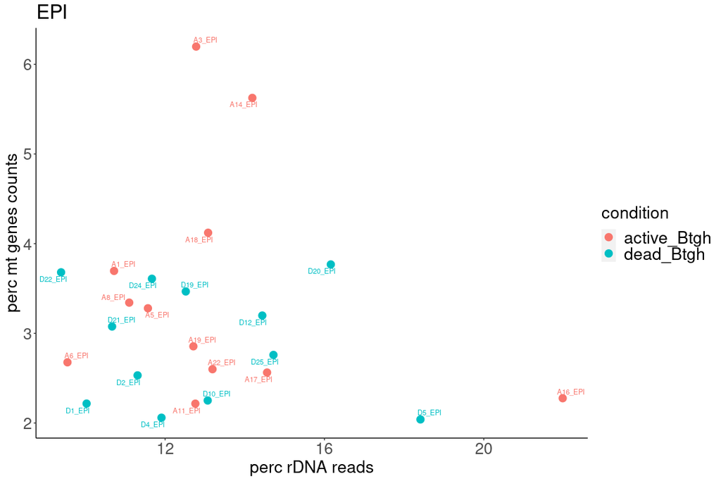

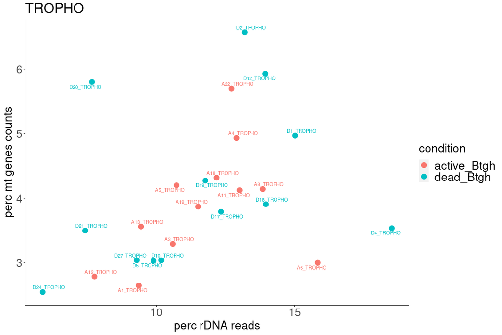

No sample shows a particularly high mtDNA gene counts and rDNA percentage.

# 3 Verifying sex of embryos

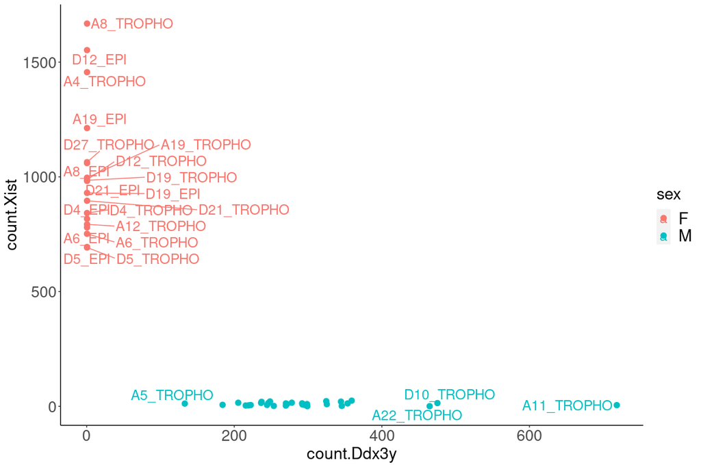

The sex established by cDNA genotyping is confirmed in silico.

# 4 Testing purity of tissues

I use 3 markers of E7 epiblast and 3 markers of E7 extraembryonic ectoderm.

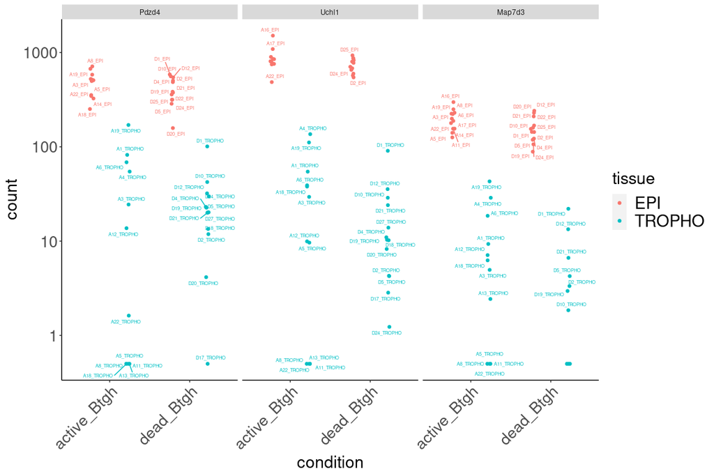

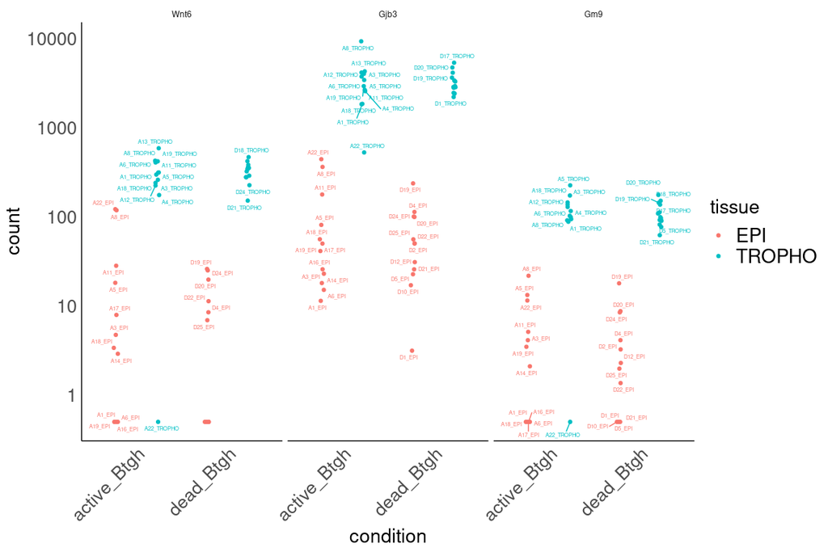

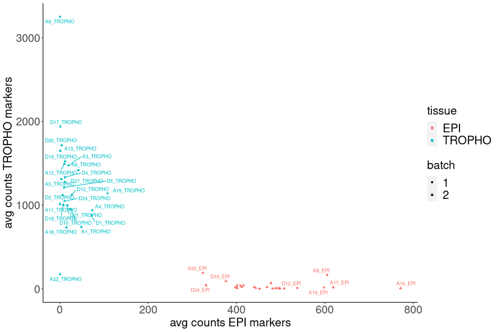

I exclude samples A22_TROPHO because outlier for the expression of both sets od markers and sample A19_TROPHO because more contaminated by EPI tissue.

# 5 Sample clustering

## 5.1 Heatmap for quality assessment

After applying the log2(n + 1) transformation, I plot heatmaps of normalized counts for top highly expressed genes to check for eventual big sample heterogeneity present in the dataset.

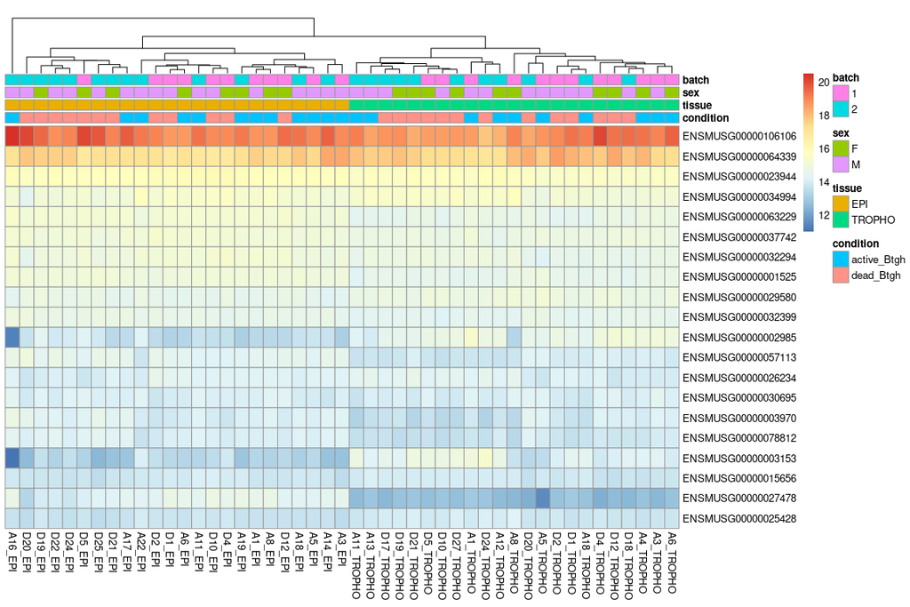

No concerns.

## 5.2 PCA

For this PCA:

1. I start with DESeq2-normalized data
2. I keep only genes with DESeq2-normalized mean across samples > 10
3. I apply log2 transformation
4. I perform PCA with package prcomp using the 1000 genes with the highest variance

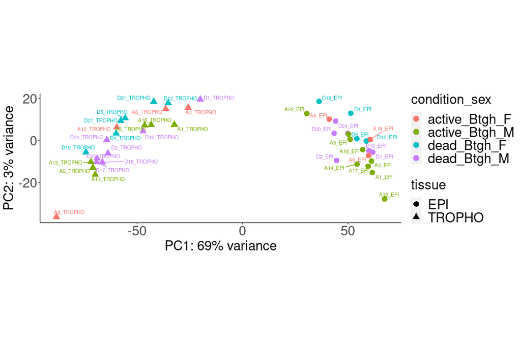

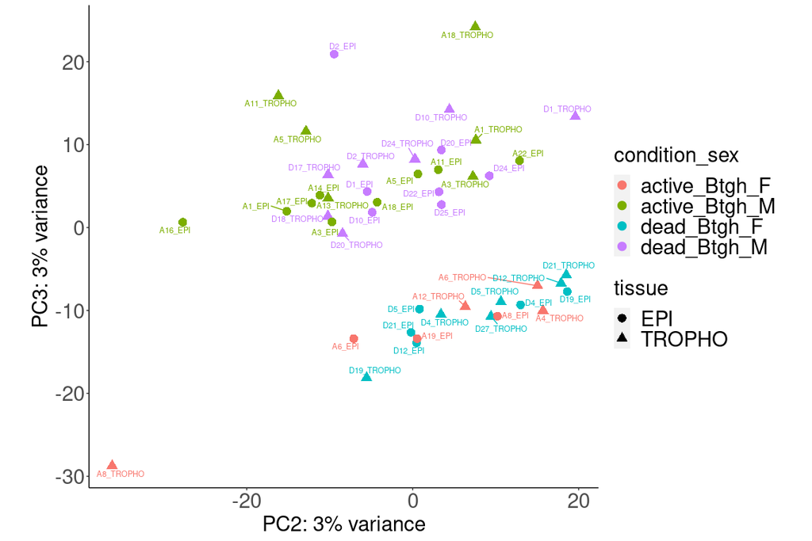

# 6 Number of samples after all filtering steps

The following numbers of embryos are left after all filtering steps. These will be input to the DE analysis in next Rmd.

|  | active_Btgh_F | active_Btgh_M | dead_Btgh_F | dead_Btgh_M |
| --- | --- | --- | --- | --- |
| EPI | 3 | 9 | 5 | 7 |
| TROPHO | 4 | 6 | 6 | 7 |